# Creating a chest

The chest entity is a coffer you place and, when opened, lets you use extra inventory slots. It’s a universal feature in most games with limited storage.

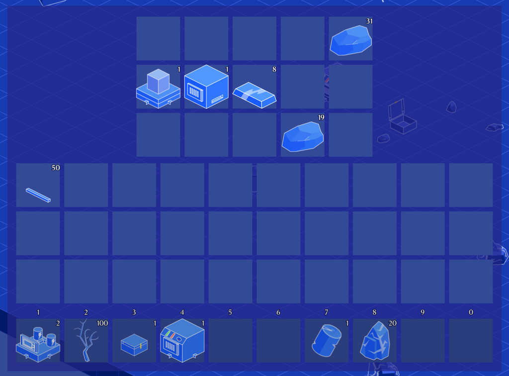

In this lesson, we’ll create both its interface, a small inventory grid, and the corresponding entity.

Let’s start with the interface.

## The chest’s inventory

Create a new scene, `ChestGUI.tscn`, with a `MarginContainer` named *ChestGUI* as its root node. Looking at the screenshot above, we have three rows of five inventory panels. We’ll instance the `InventoryBar.tscn` scene for that.

Add a `VBoxContainer` as a child, and then instance `InventoryBar.tscn` three times to make the three rows.

You can already save the scene in the `Entities/` directory and attach a new script to *ChestGUI*.

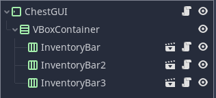

Set every inventory bar’s *Slot Count* property to `5`. That’ll give the player 15 slots per chest.

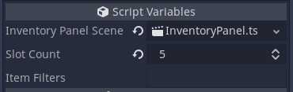

By default, it’ll anchor to the left.

Head into *ChestGUI*’s *Size Flags* property and replace *Horizontal*’s *Fill* checkbox with *Shrink Center*. This property is one way to make a `Control` node center inside its parent container.

Since our *ChestGUI*’s a `MarginContainer`, we can also add some padding around its edges with the *Custom Constants* to make it look nice.

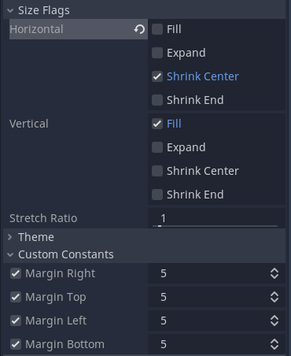

We’ll now add a script to `ChestGUI`. It extends `BaseMachineGUI` and overrides the `setup()` function, where it initializes its three inventory bars.

```
extends BaseMachineGUI


func setup(_gui: Control) -> void:
    for inventory in $VBoxContainer.get_children():
        inventory.setup(_gui)
```

## The chest blueprint

To craft and hold chests in the player’s inventory, we need to create a blueprint for it.

Create a new scene, `ChestBlueprint.tscn`, with a `BlueprintEntity` node named *ChestBlueprint* as its root and a `Sprite` as its child.

As we’ve done in previous blueprints, we want to set its *Texture* property to `blueprints.svg`, enable *Regions Enabled*, and use the *TextureRegions* toolbar to pick out the chest.

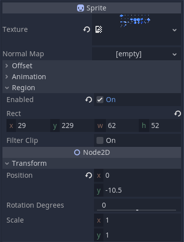

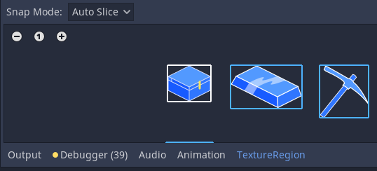

I configured the *ChestBlueprint* to only have stack of two at most.

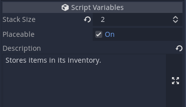

## The chest entity

We have the chest’s blueprint form, and we now need its entity to place it in the game grid.

We build the chest entity as a box and a lid, with collision data and, of course, a GUI.

When the user clicks on it, the lid swings open, and the inventory window opens.

When they close the inventory window, the lid shuts.

As with previous entities with collision, create a new scene, `ChestEntity.tscn`, with a `StaticBody2D` as its root node. Add two `Sprite`s: one for the Box, and one for the Lid.

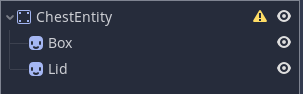

Set both of them to use `tilset.svg`, enable their *Region* data, and set them to the box and lid sprites from the sheet, respectively.

Ensure the box is raised so that its floor is at the origin and put the lid on top.

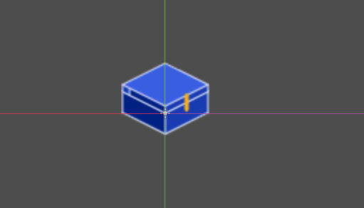

Here are the properties for the *Box* sprite first.

[figure not shown]

And here are the *Lid*’s properties.

[figure not shown]

You’ll notice there are many lid sprites in the texture atlas. They’re here to animate the lid opening and closing.

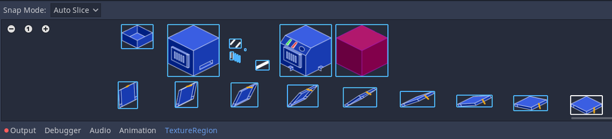

### Animating the lid opening and closing

Animating something rotating in isometric perspective can be time-consuming as you have to draw every frame to give the illusion of 3D movement.

Godot provides two tools to design the animation: the `AnimatedSprite` and the `AnimationPlayer`.

I went with a series of sprites with an `AnimationPlayer` to control them. I have two animations, “Open” and “Close”, and over the course of `0.35` seconds, scroll through each of the sprite lids I drew using the *Region Rect* property.

If your sprites are in separate images, Godot allows you to animate the *Texture* property, but as I packed them all in one image, I had to go with *Region Rect*.

Because the lid’s rotation axis is not in the sprites’ center, I also had to animate the lid’s position whenever it changes sprites until it looked good enough.

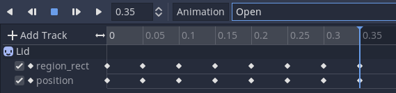

To do so, for every keyframe, I lined up the inner corner of the lid with the upper corner of the box.

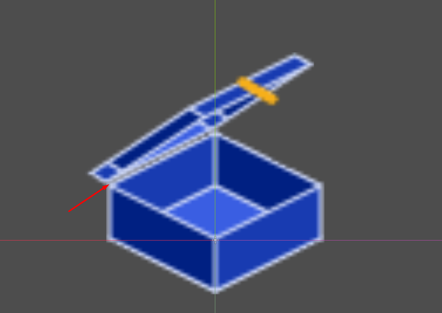

The last thing to keep in mind is that since we’re working with discrete sprites, we should be setting both the *Region rect* and *Position* keyframes to *Discrete*. Otherwise, we would get… shall we say “interesting” results.

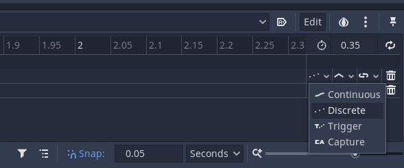

The “Close” animation is a duplicate of the “Open” one but flipped. In the *Animation* panel, you select all keyframes and use *Edit -> Scale Selection* with a *Scale Ratio* of `-1` to flip an animation.

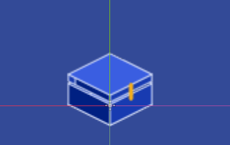

As with any static body, we need to add collision. And like previous entities, we add a `CollisionPolygon2D` to do it here.

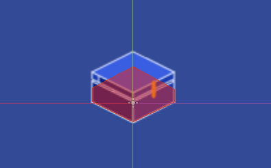

We add a `GUIComponent` node and set its *Gui Window* property to the `ChestGUI.tscn` scene.

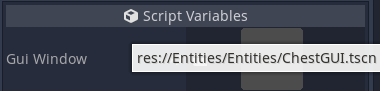

And because our scene has got a `GUIComponent`, we should also assign *ChestEntity* the `gui_entities` group in the *Node* dock.

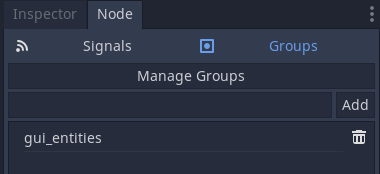

I’ve reordered the nodes to put the `GUIComponent` at the top, and here’s what your scene should contain.

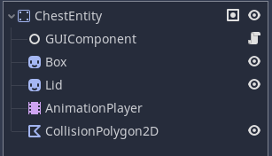

Assign a new script, `ChestEntity.gd`, to the root entity. This is where we can trigger the opening and closing animations.

```
extends Entity

onready var animation := $AnimationPlayer


func _on_GUIComponent_gui_opened() -> void:
    animation.play("Open")


func _on_GUIComponent_gui_closed() -> void:
    animation.play("Close")
```

To trigger those animations, we need to connect the signals to the appropriate functions.

Head to the inspector and connect the `gui_opened` and `gui_closed` signals from `GUIComponent` to the corresponding functions in `ChestEntity.gd`.

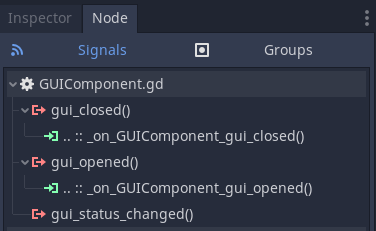

And that’s it.

If you put a chest as a child of `EntityPlacer` in `Simulation.tscn`, you should be able to approach it, click on it, put items in it, and close it by leaving the inventory.

## Preventing signal connect spam

If you run the game, everything works, but you may notice that the Debugger is raising some red errors about `held_item_changed` being already connected.

It doesn’t break the game, but it’s usually a good idea to fix red stuff and keep it from causing more trouble down the line!

The issue is we don’t know when, or even if, the player will open the machine’s GUI, so we call `setup()` even if we’ve already set the panel up before.

Doing so triggers a new call to `connect()` every time for inventory bars.

We can head to `InventoryBar.gd` then and add a boolean that checks if we’ve already run the `setup()` function. If that’s the case, we skip doing it again.

```
var setup := false

func setup(gui: Control) -> void:
    if setup:
        return

    setup = true

    #...
```

And now it’s fixed. Clean!

## Dropping the chest’s contents

At the moment, if you do a lot of work and put all your stuff in a chest, and then deconstruct the chest… all the entities within are gone.

That’s *not great*.

Instead, a machine or entity with an inventory should drop its contents when deconstructing it.

Before we can drop an inventory, we need to grab the inventory from entities.

This trip begins in `InventoryBar.gd`, where we want to get every panel from the bar’s slots into a digestible list.

```
## Returns the combined inventory of all inventory panels.
func get_inventory() -> Array:
    var output := []
    for panel in panels:
        if panel.held_item:
            output.push_back(panel.held_item)

    return output
```

After that, we head to `GUIComponent.gd` to create a helper function to collate a gui window’s inventory bars into a list.

```
# Returns an array of InventoryBar instances in the node's interface.
func get_inventory_bars() -> Array:
    var output := []
    var parent_stack := [gui]

    # We loop recursively over the interface and its children, exploring its
    # nodes to find all inventory bars.
    while not parent_stack.empty():
        var current: Node = parent_stack.pop_back()

        if current is InventoryBar:
            output.push_back(current)

        # Here's what keeps the loop going: we add the current node's children
        # to the stack until its empties.
        parent_stack += current.get_children()

    return output
```

```
func _finish_deconstruct(cellv: Vector2) -> void:
    # ...

    # We check if the entity has a GUI component and look for its inventories.
    if entity.is_in_group(Types.GUI_ENTITIES):
        var inventories: Array = _gui.find_inventory_bars_in(_gui.get_gui_component_from(entity))

        # We then loop over all inventories to find all the items they contain.
        var inventory_items := []
        for inventory in inventories:
            inventory_items += inventory.get_inventory()

        # And we drop
        for item in inventory_items:
            _drop_entity(item, location)

    #_tracker.remove_entity(cellv)
    #_update_neighboring_flat_entities(cellv)
    #_gui.deconstruct_bar.hide()


func _drop_entity(entity: BlueprintEntity, location: Vector2) -> void:
    # We instantiate dropped items as a child `GroundEntity`, but if they're
    # part of an inventory, they won't be able to be moved by the ground entity.
    # So we unparent them first if need be.
    if entity.get_parent():
        entity.get_parent().remove_child(entity)

    #var ground_entity := GroundEntityScene.instance()
    #...
```

There’s a new function on the `GUI` class we need to implement: `find_inventory_bars_in()`. This function will look through every node of a `GUIComponent` and return a list of inventory bars. This lets us grab all the inventory so we can drop it.

```
## Recursively searches the given component's GUI scene for inventory bars.
func find_inventory_bars_in(component: GUIComponent) -> Array:
    var output := []
    # Keep a stack of nodes. We will keep popping the back element from it, and add
    # all children we find to get _their_ children, so on and so forth.
    var parent_stack := [component.gui]

    # Keep searching children until there are no more nodes to search.
    while not parent_stack.empty():
        var current: Node = parent_stack.pop_back()

        if current is InventoryBar:
            output.push_back(current)

        parent_stack += current.get_children()

    return output
```

And with that, no more losing items to the aether.

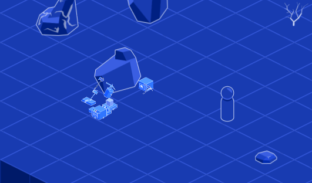

## Code reference

`ChestGUI.gd`

```
extends BaseMachineGUI


func setup(_gui: Control) -> void:
    for inventory in $VBoxContainer.get_children():
        inventory.setup(_gui)
```

`ChestEntity.gd`

```
extends Entity

onready var animation := $AnimationPlayer


func _on_GUIComponent_gui_opened() -> void:
    animation.play("Open")


func _on_GUIComponent_gui_closed() -> void:
    animation.play("Close")
```

In `InventoryBar`, we edited `setup()` and added a new `get_inventory()` function.

```
var setup := false

func setup(gui: Control) -> void:
    if setup:
        return

    setup = true

    for panel in panels:
        panel.setup(gui)
        panel.connect("held_item_changed", self, "_on_Panel_held_item_changed")


func get_inventory() -> Array:
    var output := []
    for panel in panels:
        if panel.held_item:
            output.push_back(panel.held_item)

    return output
```

In `GuiComponent.gd`, we added a function named `get_inventory_bars()`.

```
func get_inventory_bars() -> Array:
    var output := []
    var parent_stack := [gui]

    while not parent_stack.empty():
        var current: Node = parent_stack.pop_back()

        if current is InventoryBar:
            output.push_back(current)

        parent_stack += current.get_children()

    return output
```

And in `EntityPlacer.gd`, we modified `_finish_deconstruct()` and `_drop_entity()`

```
func _finish_deconstruct(cellv: Vector2) -> void:
    var entity := _tracker.get_entity_at(cellv)

    var entity_name := Library.get_entity_name_from(entity)
    var location := map_to_world(cellv)

    if Library.blueprints.has(entity_name):
        var Blueprint: PackedScene = Library.blueprints[entity_name]

        for _i in entity.pickup_count:
            _drop_entity(Blueprint.instance(), location)

    if entity.is_in_group(Types.GUI_ENTITIES):
        var inventories: Array = _gui.find_inventory_bars_in(_gui.get_gui_component_from(entity))

        var inventory_items := []
        for inventory in inventories:
            inventory_items += inventory.get_inventory()

        for item in inventory_items:
            _drop_entity(item, location)


    _tracker.remove_entity(cellv)
    _update_neighboring_flat_entities(cellv)
    _gui.deconstruct_bar.hide()


func _drop_entity(entity: BlueprintEntity, location: Vector2) -> void:
    if entity.get_parent():
        entity.get_parent().remove_child(entity)

    var ground_entity := GroundEntityScene.instance()
    add_child(ground_entity)
    ground_entity.setup(entity, location)
```

And in `GUI.gd`, we added `find_inventory_bars_in()`.

```
func find_inventory_bars_in(component: GUIComponent) -> Array:
    var output := []
    var parent_stack := [component.gui]

    while not parent_stack.empty():
        var current: Node = parent_stack.pop_back()

        if current is InventoryBar:
            output.push_back(current)

        parent_stack += current.get_children()

    return output
```